# Métodos de Gran Escala. Proyecto 2

Felipe Gerard

16 de mayo de 2015

## 1. Obtención de los datos

La fuente de los datos de avistamientos está aquí. En un proyecto anterior habíamos utilizado principalmente *R* para obtener la información de los avistamientos. Sin embargo, en esta estrategia no es muy efectiva porque no podemos tener más de 5 ó 10 instancias pidiendo información. En esta versión optamos por usar `curl` y `parallel` para bajar los HTMLs tanto de las tablas como de las descripciones largas.

Ya con la información abajo, utilizamos el comando `pup` para ayudarnos a procesar el HTML y finalmente el paquete `rvest` de *R* para pasarlo todo a formato tabla. Parte de este proceso fue el pegado de las descripciones largas a las tablas como una columna más, para lo que requerimos limpiar los textos de saltos de línea, etc.

## 2. Limpieza

Para la limpieza optamos por utilizar *PostgreSQL*. Si bien la base de UFO es pequeña y puede ser manejada en *R* sin ningún problema, optamos por pasarla por todo el proceso como práctica para la base de GDELT. Optamos por utilizar un proceso ELT, del cuál la etapa anterior corresponde a la extracción. Después de ese proceso ya teníamos la información en valores separados por pipes. Sin embargo, la base seguía estando sumanente sucia. Entonces seguía la etapa de carga a la base de datos.

Para esta parte simplemente subimos la información a una tabla de una sola columna de formato `varchar`. El objetivo era procesarla y dejarla lista para el análisis arriba en el PostgreSQL. Optamos por particionar la tabla anualmente. Para que pudiéramos utilizar la tabla como si fuera una sola, añadimos *triggers* para controlar que las inserciones en la tabla maestra se hicieran en realidad en la del año correspondiente (o en la tabla *overflow* en caso de no haber una tabla apropiada).

Para la limpieza lo que hicimos fue *castear* las columnas de manera segura a los tipos apropiados, por un lado, y por otro extraer la información relevante y transformarla a un formato útil. Por ejemplo, la duración no venía con un formato específico, así que tuvimos que extraer la cantidad y las unidades para transformarlo a segundos. Ya con la información lista, dado que como mencionábamos no son tantos datos, la pasamos a *R* para el análisis. A la hora de la lectura hubo que hacer un poco más de limpieza porque había unos pocos renglones que habían llegado mal. Y entonces podemos pasar a la etapa del análisis descriptivo.

## 3. Análisis descriptivo

```r
library(dplyr)
```

```r
library(ggplot2)
library(lubridate)
library(tidyr)
library(ggmap)
library(RColorBrewer)
setwd("/Users/Felipe/big-data/alumnos/felipegerard/proyecto2")
# Leemos la base que limpiamos en postgres
ufo <- read.table('output/ufo_usa.psv', header = T, sep = '|', quote = "", stringsAsFactors = F, fill = T,
                  colClasses = rep('character',18))

################################################################
# Limpieza aparte de lo de postgres
################################################################

data.frame(sapply(ufo,class))
```

```
##                  sapply.ufo..class.
## origin                    character
## id                        character
## date_time                 character
## year                      character
## month                     character
## day                       character
## weekday                   character
## city                      character
## state                     character
## shape                     character
## duration                  character
## number                    character
## units                     character
## seconds                   character
## summary                   character
## posted                    character
## description_url           character
## long_description          character
```

```r
for(x in c('year','month','day','weekday','number','seconds')){
  ufo[[x]] <- as.numeric(ufo[[x]])
}
ufo <- filter(ufo, nchar(origin) < 20)  %>% # Algunos renglones venían mal
  mutate(id = row_number())
dim(ufo)
```

```
## [1] 82557    18
```

Dimensiones de la base:

```r
dim(ufo)
```

```
## [1] 82557    18
```

Columnas y sus tipos:

```r
cols <- data.frame(columna=names(ufo), tipo=sapply(ufo, class), row.names = NULL)
cols$descripcion <- c('Archivo de origen del registro',
                      'ID único del registro',
                      'Fecha y hora del avistamiento',
                      'Año','Mes','Día','Día de la semana (0=domingo, 6=sábado)',
                      'Ciudad en la que fue avistado el UFO',
                      'Estado en el que fue avistado el UFO',
                      'Forma del objeto',
                      'Duración del avistamiento',
                      'Número leído del campo de duración',
                      'Unidades leídas del campo de duración',
                      'Segundos que duró el avistamiento (número*segundos/unidades)',
                      'Resumen de la descripción',
                      'Fecha y hora de subida a la base',
                      'URL de la descripción larga',
                      'Descripción larga')
cols
```

```
##             columna      tipo
## 1            origin character
## 2                id   integer
## 3         date_time character
## 4              year   numeric
## 5             month   numeric
## 6               day   numeric
## 7           weekday   numeric
## 8              city character
## 9             state character
## 10            shape character
## 11         duration character
## 12           number   numeric
## 13            units character
## 14          seconds   numeric
```

[output cut: 23 more lines]

Primeras y últimas observaciones (sin las descripciones ni la URL). Tal parece que las observaciones modernas tienen un mejor formato de duración:

```r
head(ufo %>% select(-summary, -long_description, -description_url))
```

```
##       origin id           date_time year month day weekday
## 1 ndxe187106  1 1871-06-30 14:00:00 1871     6  30       5
## 2 ndxe188012  2 1880-12-12 20:40:00 1880    12  12       0
## 3 ndxe189704  3 1897-04-17 06:00:00 1897     4  17       6
## 4 ndxe189704  4 1897-04-15 00:00:00 1897     4  15       4
## 5 ndxe189906  5 1899-06-30 07:00:00 1899     6  30       5
## 6 ndxe140006  6 1900-06-30 00:00:00 1900     6  30       6
##                        city state    shape  duration number units seconds
## 1 Yellowstone National Park    WY      egg not known     NA            NA
## 2                Bellingham    WA fireball   Unknown     NA            NA
## 3                    Aurora    TX    cigar 5 minutes      5   min     300
## 4           Howard/Artesian    SD                        NA            NA
## 5                Carrollton    MO   sphere  one hour     NA  hour      NA
## 6       Myers Spring Canyon    TX   circle       N/A     NA            NA
##                posted
## 1 2009-12-12 00:00:00
## 2 2006-12-07 00:00:00
## 3 2012-05-13 00:00:00
## 4 2005-05-11 00:00:00
## 5 2006-02-14 00:00:00
## 6 2007-02-01 00:00:00
```

```r
tail(ufo %>% select(-summary, -long_description, -description_url))
```

```
##           origin    id           date_time year month day weekday
## 82552       ndxe 82552                       NA    NA  NA      NA
## 82553       ndxe 82553                       NA    NA  NA      NA
## 82554       ndxe 82554                       NA    NA  NA      NA
## 82555       ndxe 82555                       NA    NA  NA      NA
## 82556 ndxe171502 82556 1915-02-01 03:00:00 1915     2   1       1
## 82557 ndxe179006 82557 1890-06-30 21:00:00 1890     6  30       1
##                      city state    shape           duration number units
## 82552                none    UT triangle             15 min     15   min
## 82553            San Jose    CA changing          5 minutes      5   min
## 82554            Richland    WA   sphere             10 min     10   min
## 82555     South Milwaukee    WI  unknown     1 to 2 minutes     12   min
## 82556 Truckee/Cisco Grove    CA cylinder         45 seconds     45   sec
## 82557            Carlisle    NY fireball less than 1 minute      1   min
##       seconds              posted
## 82552     900 2001-08-05 00:00:00
## 82553     300 2001-04-28 00:00:00
## 82554     600 2012-12-20 00:00:00
## 82555     720 2005-09-02 00:00:00
## 82556      45 2015-02-20 00:00:00
## 82557      60 2007-08-07 00:00:00
```

Ejemplos de descripción corta (`summary`) y descripción larga (`long_description`). Los `<n>` son saltos de línea.

```r
ufo$summary[1]
```

```
## [1] "Old photos from 1871 show what appears to be objects in the air."
```

```r
ufo$long_description[1]
```

```
## [1] " Old photos from 1871 show what appears to be objects in the air.<n> <n><n> <n><n> This is NOT a personal UFO sitting,but rather a situation where, while viewing old photographs from 1871, I came accross two pictures that had what, appeared to me, flying objects in the air.<n> <n><n> <n><n> …
```

Resumen estadístico (primero variables numéricas y luego variables de texto):

```r
col_classes <- sapply(ufo, class) %>% as.character
cols_char <- which(col_classes == 'character')
cols_num <- which(col_classes != 'character')
summary(ufo[cols_num])
```

```
##        id             year          month             day
##  Min.   :    1   Min.   :1871   Min.   : 1.000   Min.   : 1.00
##  1st Qu.:20640   1st Qu.:2001   1st Qu.: 4.000   1st Qu.: 7.00
##  Median :41279   Median :2007   Median : 7.000   Median :15.00
##  Mean   :41279   Mean   :2004   Mean   : 6.857   Mean   :15.01
##  3rd Qu.:61918   3rd Qu.:2012   3rd Qu.:10.000   3rd Qu.:22.00
##  Max.   :82557   Max.   :2015   Max.   :12.000   Max.   :31.00
##                  NA's   :191    NA's   :191      NA's   :191
##     weekday          number             seconds
##  Min.   :0.000   Min.   :        0   Min.   :0.000e+00
##  1st Qu.:1.000   1st Qu.:        3   1st Qu.:3.000e+01
##  Median :3.000   Median :        6   Median :1.800e+02
##  Mean   :3.142   Mean   :    10173   Mean   :7.495e+05
##  3rd Qu.:5.000   3rd Qu.:       18   3rd Qu.:6.000e+02
##  Max.   :6.000   Max.   :510872330   Max.   :2.602e+10
##  NA's   :191     NA's   :9358        NA's   :16159
```

```r
apply(ufo[cols_char], 2, function(x) c('length'=length(x),
                                       '# empty'=sum(x == ''),
                                       '% empty'=mean(x == ''))) %>%
  round(2) %>%
  format(scientific = F)
```

```
##         origin     date_time  city       state      shape      duration
## length  "82557.00" "82557.00" "82557.00" "82557.00" "82557.00" "82557.00"
## # empty "    0.00" "  191.00" "   85.00" "    1.00" " 2683.00" " 3002.00"
## % empty "    0.00" "    0.00" "    0.00" "    0.00" "    0.03" "    0.04"
##         units      summary    posted     description_url long_description
## length  "82557.00" "82557.00" "82557.00" "82557.00"      "82557.00"
## # empty "13057.00" "   38.00" "   55.00" "   52.00"      "  177.00"
## % empty "    0.16" "    0.00" "    0.00" "    0.00"      "    0.00"
```

## 4. Análisis

### 4.1 Preguntas cerradas

**Primer avistamiento por estado**

```r
ufo %>%
  filter(!is.na(year)) %>%
  group_by(state) %>%
  arrange(state, year) %>%
  filter(row_number() == 1) %>%
  dplyr::select(state, date_time, city, shape, duration, seconds, posted)
```

```
## Source: local data frame [54 x 7]
## Groups: state
##
##    state           date_time
## 1        1998-10-06 02:00:00
## 2     AK 1936-10-15 17:00:00
## 3     AL 1939-06-01 20:00:00
## 4     AR 1950-04-15 08:00:00
## 5     AZ 1946-09-30 20:30:00
## 6     CA 1905-06-30 03:15:00
## 7     CO 1931-02-15 14:00:00
## 8     CT 1949-06-04 10:00:00
## 9     DC 1952-07-17 00:00:00
## 10    DE 1954-06-15 11:45:00
## ..   ...                 ...
## Variables not shown: city (chr), shape (chr), duration (chr), seconds
##   (dbl), posted (chr)
```

**Primer avistamiento por forma**

```r
ufo %>%
  filter(shape != '') %>%
  group_by(shape) %>%
  arrange(shape, year) %>%
  filter(row_number() == 1) %>%
  dplyr::select(state, date_time, city, shape, duration, seconds, posted)
```

```
## Source: local data frame [30 x 7]
## Groups: shape
##
##    state           date_time                       city    shape
## 1     CO 1996-06-24 00:30:00                     Aurora  changed
## 2     IN 1954-07-12 17:30:00 Morroco (4 miles south of) changing
## 3     CA 1947-07-15 21:00:00                   San Jose  chevron
## 4     TX 1897-04-17 06:00:00                     Aurora    cigar
## 5     TX 1900-06-30 00:00:00        Myers Spring Canyon   circle
## 6     IN 1953-07-17 22:00:00                     Dublin     cone
## 7     WI 1997-03-22 22:30:00              Stevens Point crescent
## 8     NY 1961-03-29 00:00:00  New York City (Manhattan)    cross
## 9     CA 1915-02-01 03:00:00        Truckee/Cisco Grove cylinder
## 10    WA 1974-07-18 20:00:00                  Bremerton    delta
## ..   ...                 ...                        ...      ...
## Variables not shown: duration (chr), seconds (dbl), posted (chr)
```

**Número de avistamientos por año**

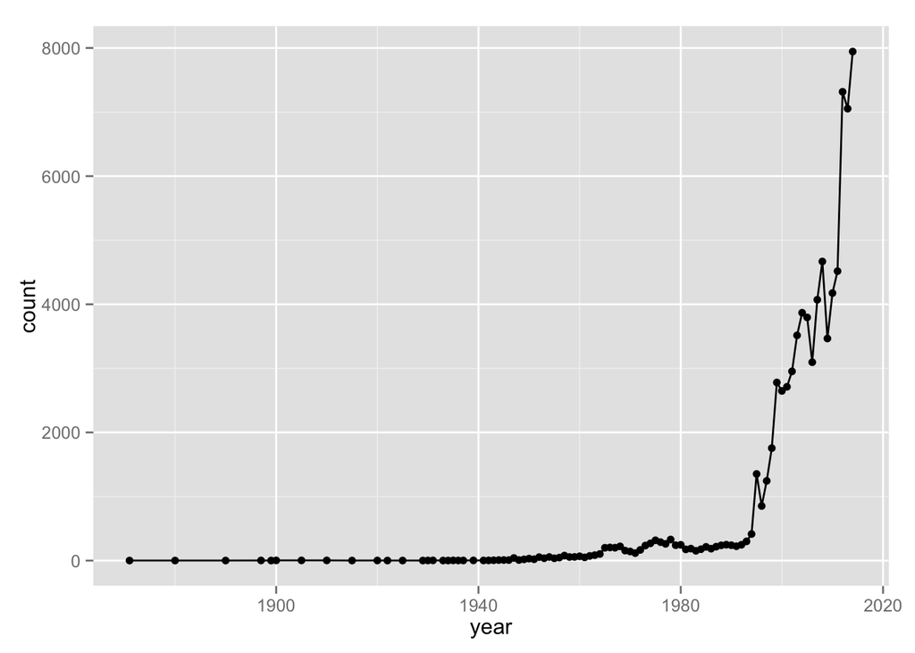

```r
yearly_sightings <- ufo %>%
  filter(date_time != '', year < 2015) %>% # Este año no está completo
  group_by(year) %>%
  summarise(count = n()) %>%
  arrange(year)
ggplot(yearly_sightings, aes(year,count)) +
  geom_line() +
  geom_point()
```

## GDELT

Hubo que optimizar PostgreSQL, hacer queries inteligentes, etc.